# Risk Factor Analysis

## Outcome Variable

**Outcome Variable:** ever_wasted

## Predictor Variables

**Intervention Variable:** feducyrs

**Adjustment Set:**

- arm
- W_mage
- meducyrs
- hhwealth_quart
- W_mhtcm
- W_gagebrth
- W_birthwt
- W_birthlen
- W_nrooms
- W_nchldlt5
- impfloor
- impsan
- safeh20
- delta_W_mage
- delta_meducyrs
- delta_hhwealth_quart
- delta_W_mhtcm
- delta_W_gagebrth
- delta_W_birthwt
- delta_W_birthlen
- delta_W_nrooms
- delta_W_nchldlt5
- delta_impfloor
- delta_impsan
- delta_safeh20

## Stratifying Variables

The analysis was stratified on these variable(s):

- agecat
- studyid
- country

## Data Summary

| agecat | studyid | country | feducyrs | ever_wasted | n_cell | n |
| --- | --- | --- | --- | --- | --- | --- |
| 0-24 months | ki0047075b-MAL-ED | BANGLADESH | Low | 0 | 23 | 147 |
| 0-24 months | ki0047075b-MAL-ED | BANGLADESH | Low | 1 | 16 | 147 |
| 0-24 months | ki0047075b-MAL-ED | BANGLADESH | Medium | 0 | 36 | 147 |
| 0-24 months | ki0047075b-MAL-ED | BANGLADESH | Medium | 1 | 18 | 147 |
| 0-24 months | ki0047075b-MAL-ED | BANGLADESH | High | 0 | 41 | 147 |
| 0-24 months | ki0047075b-MAL-ED | BANGLADESH | High | 1 | 13 | 147 |
| 0-24 months | ki0047075b-MAL-ED | INDIA | Low | 0 | 28 | 147 |
| 0-24 months | ki0047075b-MAL-ED | INDIA | Low | 1 | 31 | 147 |
| 0-24 months | ki0047075b-MAL-ED | INDIA | Medium | 0 | 27 | 147 |
| 0-24 months | ki0047075b-MAL-ED | INDIA | Medium | 1 | 17 | 147 |
| 0-24 months | ki0047075b-MAL-ED | INDIA | High | 0 | 22 | 147 |
| 0-24 months | ki0047075b-MAL-ED | INDIA | High | 1 | 22 | 147 |
| 0-24 months | ki0047075b-MAL-ED | NEPAL | Low | 0 | 18 | 98 |
| 0-24 months | ki0047075b-MAL-ED | NEPAL | Low | 1 | 10 | 98 |
| 0-24 months | ki0047075b-MAL-ED | NEPAL | Medium | 0 | 19 | 98 |
| 0-24 months | ki0047075b-MAL-ED | NEPAL | Medium | 1 | 9 | 98 |
| 0-24 months | ki0047075b-MAL-ED | NEPAL | High | 0 | 32 | 98 |
| 0-24 months | ki0047075b-MAL-ED | NEPAL | High | 1 | 10 | 98 |
| 0-24 months | ki0047075b-MAL-ED | PERU | Low | 0 | 65 | 250 |
| 0-24 months | ki0047075b-MAL-ED | PERU | Low | 1 | 4 | 250 |
| 0-24 months | ki0047075b-MAL-ED | PERU | Medium | 0 | 54 | 250 |
| 0-24 months | ki0047075b-MAL-ED | PERU | Medium | 1 | 7 | 250 |
| 0-24 months | ki0047075b-MAL-ED | PERU | High | 0 | 112 | 250 |
| 0-24 months | ki0047075b-MAL-ED | PERU | High | 1 | 8 | 250 |
| 0-24 months | ki0047075b-MAL-ED | SOUTH AFRICA | Low | 0 | 30 | 110 |
| 0-24 months | ki0047075b-MAL-ED | SOUTH AFRICA | Low | 1 | 7 | 110 |
| 0-24 months | ki0047075b-MAL-ED | SOUTH AFRICA | Medium | 0 | 23 | 110 |
| 0-24 months | ki0047075b-MAL-ED | SOUTH AFRICA | Medium | 1 | 7 | 110 |
| 0-24 months | ki0047075b-MAL-ED | SOUTH AFRICA | High | 0 | 36 | 110 |
| 0-24 months | ki0047075b-MAL-ED | SOUTH AFRICA | High | 1 | 7 | 110 |

[output cut: 330 more lines]

The following strata were considered:

- agecat: 0-24 months, studyid: ki0047075b-MAL-ED, country: BANGLADESH
- agecat: 0-24 months, studyid: ki0047075b-MAL-ED, country: INDIA
- agecat: 0-24 months, studyid: ki0047075b-MAL-ED, country: NEPAL
- agecat: 0-24 months, studyid: ki0047075b-MAL-ED, country: PERU
- agecat: 0-24 months, studyid: ki0047075b-MAL-ED, country: SOUTH AFRICA
- agecat: 0-24 months, studyid: ki0047075b-MAL-ED, country: TANZANIA, UNITED REPUBLIC OF
- agecat: 0-24 months, studyid: ki1000304b-SAS-CompFeed, country: INDIA
- agecat: 0-24 months, studyid: ki1000304b-SAS-FoodSuppl, country: INDIA
- agecat: 0-24 months, studyid: ki1017093b-PROVIDE, country: BANGLADESH
- agecat: 0-24 months, studyid: ki1017093c-NIH-Crypto, country: BANGLADESH
- agecat: 0-24 months, studyid: ki1066203-TanzaniaChild2, country: TANZANIA, UNITED REPUBLIC OF
- agecat: 0-24 months, studyid: ki1113344-GMS-Nepal, country: NEPAL
- agecat: 0-24 months, studyid: ki1119695-PROBIT, country: BELARUS
- agecat: 0-24 months, studyid: ki1126311-ZVITAMBO, country: ZIMBABWE
- agecat: 0-24 months, studyid: ki1135781-COHORTS, country: GUATEMALA
- agecat: 0-24 months, studyid: ki1135781-COHORTS, country: INDIA
- agecat: 0-24 months, studyid: ki1135781-COHORTS, country: PHILIPPINES
- agecat: 0-24 months, studyid: ki1148112-LCNI-5, country: MALAWI
- agecat: 0-24 months, studyid: kiGH5241-JiVitA-3, country: BANGLADESH
- agecat: 0-24 months, studyid: kiGH5241-JiVitA-4, country: BANGLADESH
- agecat: 0-6 months, studyid: ki0047075b-MAL-ED, country: BANGLADESH
- agecat: 0-6 months, studyid: ki0047075b-MAL-ED, country: INDIA
- agecat: 0-6 months, studyid: ki0047075b-MAL-ED, country: NEPAL
- agecat: 0-6 months, studyid: ki0047075b-MAL-ED, country: PERU
- agecat: 0-6 months, studyid: ki0047075b-MAL-ED, country: SOUTH AFRICA
- agecat: 0-6 months, studyid: ki0047075b-MAL-ED, country: TANZANIA, UNITED REPUBLIC OF
- agecat: 0-6 months, studyid: ki1000304b-SAS-CompFeed, country: INDIA
- agecat: 0-6 months, studyid: ki1000304b-SAS-FoodSuppl, country: INDIA
- agecat: 0-6 months, studyid: ki1017093b-PROVIDE, country: BANGLADESH
- agecat: 0-6 months, studyid: ki1017093c-NIH-Crypto, country: BANGLADESH
- agecat: 0-6 months, studyid: ki1066203-TanzaniaChild2, country: TANZANIA, UNITED REPUBLIC OF
- agecat: 0-6 months, studyid: ki1113344-GMS-Nepal, country: NEPAL
- agecat: 0-6 months, studyid: ki1119695-PROBIT, country: BELARUS
- agecat: 0-6 months, studyid: ki1126311-ZVITAMBO, country: ZIMBABWE
- agecat: 0-6 months, studyid: ki1135781-COHORTS, country: GUATEMALA
- agecat: 0-6 months, studyid: ki1135781-COHORTS, country: INDIA
- agecat: 0-6 months, studyid: ki1135781-COHORTS, country: PHILIPPINES
- agecat: 0-6 months, studyid: ki1148112-LCNI-5, country: MALAWI
- agecat: 0-6 months, studyid: kiGH5241-JiVitA-3, country: BANGLADESH
- agecat: 0-6 months, studyid: kiGH5241-JiVitA-4, country: BANGLADESH
- agecat: 6-24 months, studyid: ki0047075b-MAL-ED, country: BANGLADESH
- agecat: 6-24 months, studyid: ki0047075b-MAL-ED, country: INDIA
- agecat: 6-24 months, studyid: ki0047075b-MAL-ED, country: NEPAL
- agecat: 6-24 months, studyid: ki0047075b-MAL-ED, country: PERU
- agecat: 6-24 months, studyid: ki0047075b-MAL-ED, country: SOUTH AFRICA
- agecat: 6-24 months, studyid: ki0047075b-MAL-ED, country: TANZANIA, UNITED REPUBLIC OF
- agecat: 6-24 months, studyid: ki1000304b-SAS-CompFeed, country: INDIA
- agecat: 6-24 months, studyid: ki1000304b-SAS-FoodSuppl, country: INDIA
- agecat: 6-24 months, studyid: ki1017093b-PROVIDE, country: BANGLADESH
- agecat: 6-24 months, studyid: ki1017093c-NIH-Crypto, country: BANGLADESH
- agecat: 6-24 months, studyid: ki1066203-TanzaniaChild2, country: TANZANIA, UNITED REPUBLIC OF
- agecat: 6-24 months, studyid: ki1113344-GMS-Nepal, country: NEPAL
- agecat: 6-24 months, studyid: ki1119695-PROBIT, country: BELARUS
- agecat: 6-24 months, studyid: ki1126311-ZVITAMBO, country: ZIMBABWE
- agecat: 6-24 months, studyid: ki1135781-COHORTS, country: GUATEMALA
- agecat: 6-24 months, studyid: ki1135781-COHORTS, country: INDIA
- agecat: 6-24 months, studyid: ki1135781-COHORTS, country: PHILIPPINES
- agecat: 6-24 months, studyid: ki1148112-LCNI-5, country: MALAWI
- agecat: 6-24 months, studyid: kiGH5241-JiVitA-3, country: BANGLADESH
- agecat: 6-24 months, studyid: kiGH5241-JiVitA-4, country: BANGLADESH

### Dropped Strata

Some strata were dropped due to rare outcomes:

- agecat: 0-24 months, studyid: ki0047075b-MAL-ED, country: PERU
- agecat: 0-24 months, studyid: ki0047075b-MAL-ED, country: TANZANIA, UNITED REPUBLIC OF
- agecat: 0-6 months, studyid: ki0047075b-MAL-ED, country: NEPAL
- agecat: 0-6 months, studyid: ki0047075b-MAL-ED, country: PERU
- agecat: 0-6 months, studyid: ki0047075b-MAL-ED, country: SOUTH AFRICA
- agecat: 0-6 months, studyid: ki0047075b-MAL-ED, country: TANZANIA, UNITED REPUBLIC OF
- agecat: 0-6 months, studyid: ki1148112-LCNI-5, country: MALAWI
- agecat: 6-24 months, studyid: ki0047075b-MAL-ED, country: NEPAL
- agecat: 6-24 months, studyid: ki0047075b-MAL-ED, country: PERU
- agecat: 6-24 months, studyid: ki0047075b-MAL-ED, country: SOUTH AFRICA
- agecat: 6-24 months, studyid: ki0047075b-MAL-ED, country: TANZANIA, UNITED REPUBLIC OF

## Methods Detail

We’re interested in the causal parameters $E[Y_a]$ for all values of $a \in \mathcal{A}$. These parameters represent the mean outcome if, possibly contrary to fact, we intervened to set all units to have $A=a$. Under the randomization and positivity assumptions, these are identified by the statistical parameters $\psi_a=E_W[E_{Y|A,W}(Y|A=a,W)]$. In addition, we’re interested in the mean of $Y$, $E[Y]$ under no intervention (the observed mean). We will estimate these parameters by using SuperLearner to fit the relevant likelihood factors – $E_{Y|A,W}(Y|A=a,W)$ and $p(A=a|W)$, and then updating our likelihood fit using a joint TMLE.

For unadjusted analyses ($W=\{\}$), initial likelihoods were estimated using Lrnr_glm to estimate the simple $E(Y|A)$ and Lrnr_mean to estimate $p(A)$. For adjusted analyses, a small library containing Lrnr_glmnet, Lrnr_xgboost, and Lrnr_mean was used.

Having estimated these parameters, we will then use the delta method to estimate relative risks and attributable risks relative to a prespecified baseline level of $A$.

# Results Detail

## Results Plots

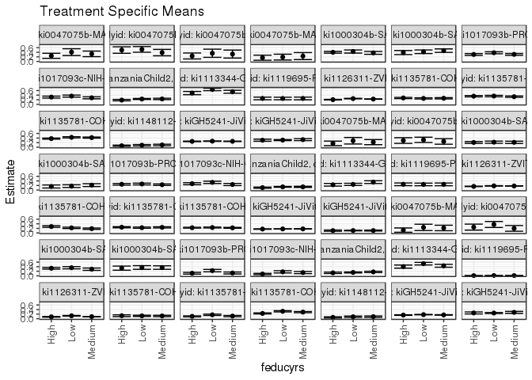

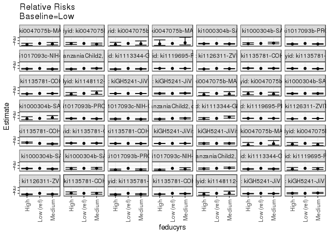

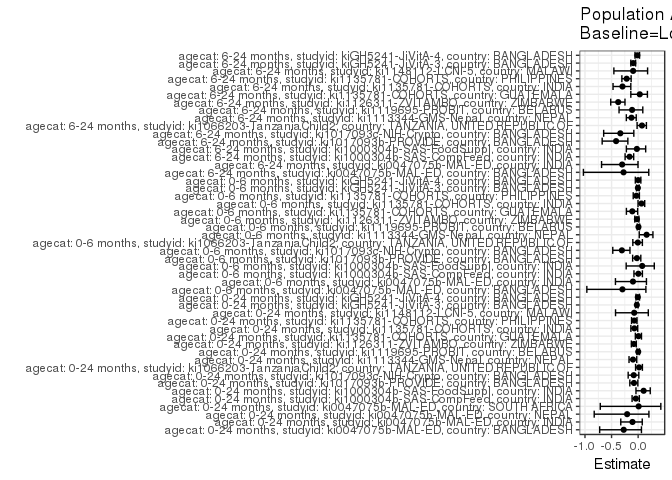

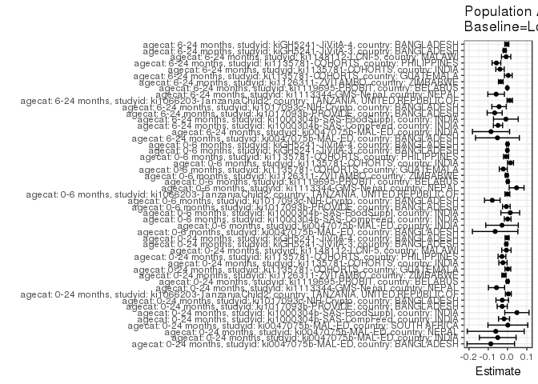

## Results Table

### Parameter: TSM

| agecat | studyid | country | intervention_level | baseline_level | estimate | ci_lower | ci_upper |
| --- | --- | --- | --- | --- | --- | --- | --- |
| 0-24 months | ki0047075b-MAL-ED | BANGLADESH | Low | NA | 0.4065516 | 0.2583426 | 0.5547607 |
| 0-24 months | ki0047075b-MAL-ED | BANGLADESH | Medium | NA | 0.3316492 | 0.2102242 | 0.4530743 |
| 0-24 months | ki0047075b-MAL-ED | BANGLADESH | High | NA | 0.2453783 | 0.1349697 | 0.3557868 |
| 0-24 months | ki0047075b-MAL-ED | INDIA | Low | NA | 0.5269210 | 0.4026353 | 0.6512067 |
| 0-24 months | ki0047075b-MAL-ED | INDIA | Medium | NA | 0.3861048 | 0.2466403 | 0.5255694 |
| 0-24 months | ki0047075b-MAL-ED | INDIA | High | NA | 0.4976808 | 0.3559142 | 0.6394473 |
| 0-24 months | ki0047075b-MAL-ED | NEPAL | Low | NA | 0.3571429 | 0.1787512 | 0.5355345 |
| 0-24 months | ki0047075b-MAL-ED | NEPAL | Medium | NA | 0.3214286 | 0.1475539 | 0.4953032 |
| 0-24 months | ki0047075b-MAL-ED | NEPAL | High | NA | 0.2380952 | 0.1086231 | 0.3675674 |
| 0-24 months | ki0047075b-MAL-ED | SOUTH AFRICA | Low | NA | 0.1891892 | 0.0624128 | 0.3159655 |
| 0-24 months | ki0047075b-MAL-ED | SOUTH AFRICA | Medium | NA | 0.2333333 | 0.0812918 | 0.3853749 |
| 0-24 months | ki0047075b-MAL-ED | SOUTH AFRICA | High | NA | 0.1627907 | 0.0519425 | 0.2736389 |
| 0-24 months | ki1000304b-SAS-CompFeed | INDIA | Low | NA | 0.4326920 | 0.3643376 | 0.5010464 |
| 0-24 months | ki1000304b-SAS-CompFeed | INDIA | Medium | NA | 0.3740554 | 0.3114981 | 0.4366127 |
| 0-24 months | ki1000304b-SAS-CompFeed | INDIA | High | NA | 0.3992675 | 0.3605521 | 0.4379828 |
| 0-24 months | ki1000304b-SAS-FoodSuppl | INDIA | Low | NA | 0.4226176 | 0.3444343 | 0.5008008 |
| 0-24 months | ki1000304b-SAS-FoodSuppl | INDIA | Medium | NA | 0.4709976 | 0.3956094 | 0.5463858 |
| 0-24 months | ki1000304b-SAS-FoodSuppl | INDIA | High | NA | 0.3874214 | 0.2980480 | 0.4767948 |
| 0-24 months | ki1017093b-PROVIDE | BANGLADESH | Low | NA | 0.3790172 | 0.3359296 | 0.4221047 |
| 0-24 months | ki1017093b-PROVIDE | BANGLADESH | Medium | NA | 0.3090164 | 0.2697653 | 0.3482676 |
| 0-24 months | ki1017093b-PROVIDE | BANGLADESH | High | NA | 0.3049915 | 0.2652833 | 0.3446997 |
| 0-24 months | ki1017093c-NIH-Crypto | BANGLADESH | Low | NA | 0.3586138 | 0.3145312 | 0.4026964 |
| 0-24 months | ki1017093c-NIH-Crypto | BANGLADESH | Medium | NA | 0.2843785 | 0.2409896 | 0.3277675 |
| 0-24 months | ki1017093c-NIH-Crypto | BANGLADESH | High | NA | 0.3148163 | 0.2728496 | 0.3567830 |
| 0-24 months | ki1066203-TanzaniaChild2 | TANZANIA, UNITED REPUBLIC OF | Low | NA | 0.2324352 | 0.2101015 | 0.2547690 |
| 0-24 months | ki1066203-TanzaniaChild2 | TANZANIA, UNITED REPUBLIC OF | Medium | NA | 0.2354061 | 0.2060380 | 0.2647742 |
| 0-24 months | ki1066203-TanzaniaChild2 | TANZANIA, UNITED REPUBLIC OF | High | NA | 0.1836597 | 0.1534890 | 0.2138303 |
| 0-24 months | ki1113344-GMS-Nepal | NEPAL | Low | NA | 0.6478405 | 0.5945461 | 0.7011349 |
| 0-24 months | ki1113344-GMS-Nepal | NEPAL | Medium | NA | 0.5488237 | 0.4858570 | 0.6117903 |
| 0-24 months | ki1113344-GMS-Nepal | NEPAL | High | NA | 0.4901040 | 0.4206947 | 0.5595134 |

[output cut: 117 more lines]

### Parameter: E(Y)

| agecat | studyid | country | intervention_level | baseline_level | estimate | ci_lower | ci_upper |
| --- | --- | --- | --- | --- | --- | --- | --- |
| 0-24 months | ki0047075b-MAL-ED | BANGLADESH | NA | NA | 0.3197279 | 0.2440789 | 0.3953769 |
| 0-24 months | ki0047075b-MAL-ED | INDIA | NA | NA | 0.4761905 | 0.3951786 | 0.5572024 |
| 0-24 months | ki0047075b-MAL-ED | NEPAL | NA | NA | 0.2959184 | 0.2050820 | 0.3867547 |
| 0-24 months | ki0047075b-MAL-ED | SOUTH AFRICA | NA | NA | 0.1909091 | 0.1171277 | 0.2646905 |
| 0-24 months | ki1000304b-SAS-CompFeed | INDIA | NA | NA | 0.4145695 | 0.3576236 | 0.4715155 |
| 0-24 months | ki1000304b-SAS-FoodSuppl | INDIA | NA | NA | 0.4712919 | 0.4233811 | 0.5192026 |
| 0-24 months | ki1017093b-PROVIDE | BANGLADESH | NA | NA | 0.3514286 | 0.3160364 | 0.3868207 |
| 0-24 months | ki1017093c-NIH-Crypto | BANGLADESH | NA | NA | 0.3311346 | 0.2976093 | 0.3646598 |
| 0-24 months | ki1066203-TanzaniaChild2 | TANZANIA, UNITED REPUBLIC OF | NA | NA | 0.2366765 | 0.2196074 | 0.2537455 |
| 0-24 months | ki1113344-GMS-Nepal | NEPAL | NA | NA | 0.5906822 | 0.5513381 | 0.6300263 |
| 0-24 months | ki1119695-PROBIT | BELARUS | NA | NA | 0.2556543 | 0.1980936 | 0.3132150 |
| 0-24 months | ki1126311-ZVITAMBO | ZIMBABWE | NA | NA | 0.2317505 | 0.2246488 | 0.2388522 |
| 0-24 months | ki1135781-COHORTS | GUATEMALA | NA | NA | 0.2601297 | 0.2356425 | 0.2846169 |
| 0-24 months | ki1135781-COHORTS | INDIA | NA | NA | 0.3365584 | 0.3122030 | 0.3609138 |
| 0-24 months | ki1135781-COHORTS | PHILIPPINES | NA | NA | 0.4013250 | 0.3833827 | 0.4192673 |
| 0-24 months | ki1148112-LCNI-5 | MALAWI | NA | NA | 0.0799508 | 0.0612962 | 0.0986054 |
| 0-24 months | kiGH5241-JiVitA-3 | BANGLADESH | NA | NA | 0.2575635 | 0.2509808 | 0.2641462 |
| 0-24 months | kiGH5241-JiVitA-4 | BANGLADESH | NA | NA | 0.3085018 | 0.2890487 | 0.3279548 |
| 0-6 months | ki0047075b-MAL-ED | BANGLADESH | NA | NA | 0.2176871 | 0.1507482 | 0.2846259 |
| 0-6 months | ki0047075b-MAL-ED | INDIA | NA | NA | 0.2925170 | 0.2187257 | 0.3663083 |
| 0-6 months | ki1000304b-SAS-CompFeed | INDIA | NA | NA | 0.2197071 | 0.1750081 | 0.2644060 |
| 0-6 months | ki1000304b-SAS-FoodSuppl | INDIA | NA | NA | 0.1866029 | 0.1492099 | 0.2239959 |
| 0-6 months | ki1017093b-PROVIDE | BANGLADESH | NA | NA | 0.2585714 | 0.2261125 | 0.2910304 |
| 0-6 months | ki1017093c-NIH-Crypto | BANGLADESH | NA | NA | 0.2585752 | 0.2273844 | 0.2897660 |
| 0-6 months | ki1066203-TanzaniaChild2 | TANZANIA, UNITED REPUBLIC OF | NA | NA | 0.1397398 | 0.1258162 | 0.1536634 |
| 0-6 months | ki1113344-GMS-Nepal | NEPAL | NA | NA | 0.2961730 | 0.2596406 | 0.3327054 |
| 0-6 months | ki1119695-PROBIT | BELARUS | NA | NA | 0.2487739 | 0.1904535 | 0.3070943 |
| 0-6 months | ki1126311-ZVITAMBO | ZIMBABWE | NA | NA | 0.1794091 | 0.1729298 | 0.1858885 |
| 0-6 months | ki1135781-COHORTS | GUATEMALA | NA | NA | 0.2006018 | 0.1757323 | 0.2254713 |
| 0-6 months | ki1135781-COHORTS | INDIA | NA | NA | 0.2462950 | 0.2238538 | 0.2687361 |
| 0-6 months | ki1135781-COHORTS | PHILIPPINES | NA | NA | 0.2291594 | 0.2137721 | 0.2445467 |
| 0-6 months | kiGH5241-JiVitA-3 | BANGLADESH | NA | NA | 0.1758866 | 0.1701478 | 0.1816254 |
| 0-6 months | kiGH5241-JiVitA-4 | BANGLADESH | NA | NA | 0.1055729 | 0.0925062 | 0.1186395 |
| 6-24 months | ki0047075b-MAL-ED | BANGLADESH | NA | NA | 0.1908397 | 0.1232893 | 0.2583901 |
| 6-24 months | ki0047075b-MAL-ED | INDIA | NA | NA | 0.2846715 | 0.2088306 | 0.3605124 |
| 6-24 months | ki1000304b-SAS-CompFeed | INDIA | NA | NA | 0.3051948 | 0.2633957 | 0.3469939 |
| 6-24 months | ki1000304b-SAS-FoodSuppl | INDIA | NA | NA | 0.3557214 | 0.3088651 | 0.4025777 |
| 6-24 months | ki1017093b-PROVIDE | BANGLADESH | NA | NA | 0.1609756 | 0.1319065 | 0.1900447 |
| 6-24 months | ki1017093c-NIH-Crypto | BANGLADESH | NA | NA | 0.1315068 | 0.1069744 | 0.1560393 |
| 6-24 months | ki1066203-TanzaniaChild2 | TANZANIA, UNITED REPUBLIC OF | NA | NA | 0.1602787 | 0.1442326 | 0.1763249 |
| 6-24 months | ki1113344-GMS-Nepal | NEPAL | NA | NA | 0.4719864 | 0.4316361 | 0.5123367 |
| 6-24 months | ki1119695-PROBIT | BELARUS | NA | NA | 0.0102327 | 0.0075781 | 0.0128874 |
| 6-24 months | ki1126311-ZVITAMBO | ZIMBABWE | NA | NA | 0.0926247 | 0.0870490 | 0.0982004 |
| 6-24 months | ki1135781-COHORTS | GUATEMALA | NA | NA | 0.1288889 | 0.1093000 | 0.1484778 |
| 6-24 months | ki1135781-COHORTS | INDIA | NA | NA | 0.1323843 | 0.1146569 | 0.1501118 |
| 6-24 months | ki1135781-COHORTS | PHILIPPINES | NA | NA | 0.2666667 | 0.2498425 | 0.2834908 |
| 6-24 months | ki1148112-LCNI-5 | MALAWI | NA | NA | 0.0773067 | 0.0588111 | 0.0958024 |
| 6-24 months | kiGH5241-JiVitA-3 | BANGLADESH | NA | NA | 0.1644249 | 0.1581893 | 0.1706604 |
| 6-24 months | kiGH5241-JiVitA-4 | BANGLADESH | NA | NA | 0.2442659 | 0.2256986 | 0.2628332 |

### Parameter: RR

| agecat | studyid | country | intervention_level | baseline_level | estimate | ci_lower | ci_upper |
| --- | --- | --- | --- | --- | --- | --- | --- |
| 0-24 months | ki0047075b-MAL-ED | BANGLADESH | Low | Low | 1.0000000 | 1.0000000 | 1.0000000 |
| 0-24 months | ki0047075b-MAL-ED | BANGLADESH | Medium | Low | 0.8157616 | 0.4903223 | 1.3572034 |
| 0-24 months | ki0047075b-MAL-ED | BANGLADESH | High | Low | 0.6035599 | 0.3408427 | 1.0687762 |
| 0-24 months | ki0047075b-MAL-ED | INDIA | Low | Low | 1.0000000 | 1.0000000 | 1.0000000 |
| 0-24 months | ki0047075b-MAL-ED | INDIA | Medium | Low | 0.7327566 | 0.4774872 | 1.1244955 |
| 0-24 months | ki0047075b-MAL-ED | INDIA | High | Low | 0.9445074 | 0.6556407 | 1.3606449 |
| 0-24 months | ki0047075b-MAL-ED | NEPAL | Low | Low | 1.0000000 | 1.0000000 | 1.0000000 |
| 0-24 months | ki0047075b-MAL-ED | NEPAL | Medium | Low | 0.9000000 | 0.4310005 | 1.8793484 |
| 0-24 months | ki0047075b-MAL-ED | NEPAL | High | Low | 0.6666667 | 0.3185934 | 1.3950207 |
| 0-24 months | ki0047075b-MAL-ED | SOUTH AFRICA | Low | Low | 1.0000000 | 1.0000000 | 1.0000000 |
| 0-24 months | ki0047075b-MAL-ED | SOUTH AFRICA | Medium | Low | 1.2333333 | 0.4843434 | 3.1405635 |
| 0-24 months | ki0047075b-MAL-ED | SOUTH AFRICA | High | Low | 0.8604651 | 0.3310009 | 2.2368526 |
| 0-24 months | ki1000304b-SAS-CompFeed | INDIA | Low | Low | 1.0000000 | 1.0000000 | 1.0000000 |
| 0-24 months | ki1000304b-SAS-CompFeed | INDIA | Medium | Low | 0.8644842 | 0.7544288 | 0.9905944 |
| 0-24 months | ki1000304b-SAS-CompFeed | INDIA | High | Low | 0.9227521 | 0.8165771 | 1.0427325 |
| 0-24 months | ki1000304b-SAS-FoodSuppl | INDIA | Low | Low | 1.0000000 | 1.0000000 | 1.0000000 |
| 0-24 months | ki1000304b-SAS-FoodSuppl | INDIA | Medium | Low | 1.1144771 | 0.8730630 | 1.4226455 |
| 0-24 months | ki1000304b-SAS-FoodSuppl | INDIA | High | Low | 0.9167187 | 0.6822809 | 1.2317114 |
| 0-24 months | ki1017093b-PROVIDE | BANGLADESH | Low | Low | 1.0000000 | 1.0000000 | 1.0000000 |
| 0-24 months | ki1017093b-PROVIDE | BANGLADESH | Medium | Low | 0.8153099 | 0.7167984 | 0.9273601 |
| 0-24 months | ki1017093b-PROVIDE | BANGLADESH | High | Low | 0.8046906 | 0.7029766 | 0.9211216 |
| 0-24 months | ki1017093c-NIH-Crypto | BANGLADESH | Low | Low | 1.0000000 | 1.0000000 | 1.0000000 |
| 0-24 months | ki1017093c-NIH-Crypto | BANGLADESH | Medium | Low | 0.7929939 | 0.6669602 | 0.9428439 |
| 0-24 months | ki1017093c-NIH-Crypto | BANGLADESH | High | Low | 0.8778701 | 0.7475045 | 1.0309717 |
| 0-24 months | ki1066203-TanzaniaChild2 | TANZANIA, UNITED REPUBLIC OF | Low | Low | 1.0000000 | 1.0000000 | 1.0000000 |
| 0-24 months | ki1066203-TanzaniaChild2 | TANZANIA, UNITED REPUBLIC OF | Medium | Low | 1.0127814 | 0.8658395 | 1.1846609 |
| 0-24 months | ki1066203-TanzaniaChild2 | TANZANIA, UNITED REPUBLIC OF | High | Low | 0.7901542 | 0.6537362 | 0.9550392 |
| 0-24 months | ki1113344-GMS-Nepal | NEPAL | Low | Low | 1.0000000 | 1.0000000 | 1.0000000 |
| 0-24 months | ki1113344-GMS-Nepal | NEPAL | Medium | Low | 0.8471586 | 0.7356400 | 0.9755827 |
| 0-24 months | ki1113344-GMS-Nepal | NEPAL | High | Low | 0.7565196 | 0.6421384 | 0.8912750 |

[output cut: 117 more lines]

### Parameter: PAR

| agecat | studyid | country | intervention_level | baseline_level | estimate | ci_lower | ci_upper |
| --- | --- | --- | --- | --- | --- | --- | --- |
| 0-24 months | ki0047075b-MAL-ED | BANGLADESH | Low | NA | -0.0868238 | -0.2099901 | 0.0363426 |
| 0-24 months | ki0047075b-MAL-ED | INDIA | Low | NA | -0.0507305 | -0.1458874 | 0.0444264 |
| 0-24 months | ki0047075b-MAL-ED | NEPAL | Low | NA | -0.0612245 | -0.2091769 | 0.0867279 |
| 0-24 months | ki0047075b-MAL-ED | SOUTH AFRICA | Low | NA | 0.0017199 | -0.1017388 | 0.1051786 |
| 0-24 months | ki1000304b-SAS-CompFeed | INDIA | Low | NA | -0.0181225 | -0.0467349 | 0.0104899 |
| 0-24 months | ki1000304b-SAS-FoodSuppl | INDIA | Low | NA | 0.0486743 | -0.0143137 | 0.1116623 |
| 0-24 months | ki1017093b-PROVIDE | BANGLADESH | Low | NA | -0.0275886 | -0.0538200 | -0.0013571 |
| 0-24 months | ki1017093c-NIH-Crypto | BANGLADESH | Low | NA | -0.0274792 | -0.0601568 | 0.0051983 |
| 0-24 months | ki1066203-TanzaniaChild2 | TANZANIA, UNITED REPUBLIC OF | Low | NA | 0.0042412 | -0.0109314 | 0.0194139 |
| 0-24 months | ki1113344-GMS-Nepal | NEPAL | Low | NA | -0.0571583 | -0.0992116 | -0.0151050 |
| 0-24 months | ki1119695-PROBIT | BELARUS | Low | NA | 0.0003612 | -0.0057458 | 0.0064681 |
| 0-24 months | ki1126311-ZVITAMBO | ZIMBABWE | Low | NA | -0.0185674 | -0.0293018 | -0.0078331 |
| 0-24 months | ki1135781-COHORTS | GUATEMALA | Low | NA | 0.0017197 | -0.0133455 | 0.0167848 |
| 0-24 months | ki1135781-COHORTS | INDIA | Low | NA | -0.0238497 | -0.0452265 | -0.0024730 |
| 0-24 months | ki1135781-COHORTS | PHILIPPINES | Low | NA | -0.0288954 | -0.0491256 | -0.0086651 |
| 0-24 months | ki1148112-LCNI-5 | MALAWI | Low | NA | -0.0059144 | -0.0301649 | 0.0183360 |
| 0-24 months | kiGH5241-JiVitA-3 | BANGLADESH | Low | NA | -0.0063958 | -0.0124100 | -0.0003816 |
| 0-24 months | kiGH5241-JiVitA-4 | BANGLADESH | Low | NA | -0.0021095 | -0.0124418 | 0.0082227 |
| 0-6 months | ki0047075b-MAL-ED | BANGLADESH | Low | NA | -0.0643642 | -0.1822934 | 0.0535649 |
| 0-6 months | ki0047075b-MAL-ED | INDIA | Low | NA | -0.0285193 | -0.1128201 | 0.0557815 |
| 0-6 months | ki1000304b-SAS-CompFeed | INDIA | Low | NA | 0.0008070 | -0.0166527 | 0.0182666 |
| 0-6 months | ki1000304b-SAS-FoodSuppl | INDIA | Low | NA | 0.0142221 | -0.0345229 | 0.0629670 |
| 0-6 months | ki1017093b-PROVIDE | BANGLADESH | Low | NA | -0.0061734 | -0.0259998 | 0.0136529 |
| 0-6 months | ki1017093c-NIH-Crypto | BANGLADESH | Low | NA | -0.0790639 | -0.1195622 | -0.0385657 |
| 0-6 months | ki1066203-TanzaniaChild2 | TANZANIA, UNITED REPUBLIC OF | Low | NA | -0.0008850 | -0.0134120 | 0.0116420 |
| 0-6 months | ki1113344-GMS-Nepal | NEPAL | Low | NA | 0.0471670 | 0.0086791 | 0.0856550 |
| 0-6 months | ki1119695-PROBIT | BELARUS | Low | NA | 0.0014676 | -0.0043013 | 0.0072364 |
| 0-6 months | ki1126311-ZVITAMBO | ZIMBABWE | Low | NA | -0.0042272 | -0.0111885 | 0.0027341 |
| 0-6 months | ki1135781-COHORTS | GUATEMALA | Low | NA | -0.0220684 | -0.0427611 | -0.0013756 |
| 0-6 months | ki1135781-COHORTS | INDIA | Low | NA | 0.0154299 | -0.0001414 | 0.0310012 |
| 0-6 months | ki1135781-COHORTS | PHILIPPINES | Low | NA | -0.0075699 | -0.0208079 | 0.0056681 |
| 0-6 months | kiGH5241-JiVitA-3 | BANGLADESH | Low | NA | -0.0008806 | -0.0053043 | 0.0035431 |
| 0-6 months | kiGH5241-JiVitA-4 | BANGLADESH | Low | NA | 0.0000188 | -0.0054788 | 0.0055164 |
| 6-24 months | ki0047075b-MAL-ED | BANGLADESH | Low | NA | -0.0524035 | -0.1661693 | 0.0613622 |
| 6-24 months | ki0047075b-MAL-ED | INDIA | Low | NA | -0.0856988 | -0.1820795 | 0.0106818 |
| 6-24 months | ki1000304b-SAS-CompFeed | INDIA | Low | NA | -0.0494280 | -0.0733981 | -0.0254578 |
| 6-24 months | ki1000304b-SAS-FoodSuppl | INDIA | Low | NA | -0.0085643 | -0.0728197 | 0.0556911 |
| 6-24 months | ki1017093b-PROVIDE | BANGLADESH | Low | NA | -0.0667675 | -0.1057611 | -0.0277738 |
| 6-24 months | ki1017093c-NIH-Crypto | BANGLADESH | Low | NA | -0.0440798 | -0.0815365 | -0.0066231 |
| 6-24 months | ki1066203-TanzaniaChild2 | TANZANIA, UNITED REPUBLIC OF | Low | NA | 0.0115115 | -0.0025496 | 0.0255726 |
| 6-24 months | ki1113344-GMS-Nepal | NEPAL | Low | NA | -0.0591489 | -0.1022169 | -0.0160808 |
| 6-24 months | ki1119695-PROBIT | BELARUS | Low | NA | -0.0011648 | -0.0035358 | 0.0012062 |
| 6-24 months | ki1126311-ZVITAMBO | ZIMBABWE | Low | NA | -0.0347584 | -0.0469939 | -0.0225230 |
| 6-24 months | ki1135781-COHORTS | GUATEMALA | Low | NA | 0.0039475 | -0.0160981 | 0.0239931 |
| 6-24 months | ki1135781-COHORTS | INDIA | Low | NA | -0.0389850 | -0.0608835 | -0.0170864 |
| 6-24 months | ki1135781-COHORTS | PHILIPPINES | Low | NA | -0.0575888 | -0.0802567 | -0.0349209 |
| 6-24 months | ki1148112-LCNI-5 | MALAWI | Low | NA | -0.0073058 | -0.0314685 | 0.0168568 |
| 6-24 months | kiGH5241-JiVitA-3 | BANGLADESH | Low | NA | -0.0150967 | -0.0225271 | -0.0076663 |
| 6-24 months | kiGH5241-JiVitA-4 | BANGLADESH | Low | NA | -0.0037939 | -0.0142527 | 0.0066649 |

### Parameter: PAF

| agecat | studyid | country | intervention_level | baseline_level | estimate | ci_lower | ci_upper |
| --- | --- | --- | --- | --- | --- | --- | --- |
| 0-24 months | ki0047075b-MAL-ED | BANGLADESH | Low | NA | -0.2715551 | -0.7237384 | 0.0620082 |
| 0-24 months | ki0047075b-MAL-ED | INDIA | Low | NA | -0.1065341 | -0.3267669 | 0.0771418 |
| 0-24 months | ki0047075b-MAL-ED | NEPAL | Low | NA | -0.2068966 | -0.8264376 | 0.2024916 |
| 0-24 months | ki0047075b-MAL-ED | SOUTH AFRICA | Low | NA | 0.0090090 | -0.7122310 | 0.4264424 |
| 0-24 months | ki1000304b-SAS-CompFeed | INDIA | Low | NA | -0.0437139 | -0.1141353 | 0.0222563 |
| 0-24 months | ki1000304b-SAS-FoodSuppl | INDIA | Low | NA | 0.1032785 | -0.0410198 | 0.2275752 |
| 0-24 months | ki1017093b-PROVIDE | BANGLADESH | Low | NA | -0.0785041 | -0.1566188 | -0.0056650 |
| 0-24 months | ki1017093c-NIH-Crypto | BANGLADESH | Low | NA | -0.0829851 | -0.1877315 | 0.0125238 |
| 0-24 months | ki1066203-TanzaniaChild2 | TANZANIA, UNITED REPUBLIC OF | Low | NA | 0.0179199 | -0.0482792 | 0.0799384 |
| 0-24 months | ki1113344-GMS-Nepal | NEPAL | Low | NA | -0.0967666 | -0.1716133 | -0.0267014 |
| 0-24 months | ki1119695-PROBIT | BELARUS | Low | NA | 0.0014127 | -0.0226731 | 0.0249312 |
| 0-24 months | ki1126311-ZVITAMBO | ZIMBABWE | Low | NA | -0.0801182 | -0.1275330 | -0.0346973 |
| 0-24 months | ki1135781-COHORTS | GUATEMALA | Low | NA | 0.0066108 | -0.0528907 | 0.0627496 |
| 0-24 months | ki1135781-COHORTS | INDIA | Low | NA | -0.0708636 | -0.1369847 | -0.0085877 |
| 0-24 months | ki1135781-COHORTS | PHILIPPINES | Low | NA | -0.0720000 | -0.1240646 | -0.0223469 |
| 0-24 months | ki1148112-LCNI-5 | MALAWI | Low | NA | -0.0739758 | -0.4252975 | 0.1907486 |
| 0-24 months | kiGH5241-JiVitA-3 | BANGLADESH | Low | NA | -0.0248319 | -0.0484903 | -0.0017073 |
| 0-24 months | kiGH5241-JiVitA-4 | BANGLADESH | Low | NA | -0.0068380 | -0.0408752 | 0.0260861 |
| 0-6 months | ki0047075b-MAL-ED | BANGLADESH | Low | NA | -0.2956731 | -0.9650094 | 0.1456689 |
| 0-6 months | ki0047075b-MAL-ED | INDIA | Low | NA | -0.0974962 | -0.4270470 | 0.1559508 |
| 0-6 months | ki1000304b-SAS-CompFeed | INDIA | Low | NA | 0.0036729 | -0.0790052 | 0.0800159 |
| 0-6 months | ki1000304b-SAS-FoodSuppl | INDIA | Low | NA | 0.0762157 | -0.2251324 | 0.3034406 |
| 0-6 months | ki1017093b-PROVIDE | BANGLADESH | Low | NA | -0.0238752 | -0.1035370 | 0.0500360 |
| 0-6 months | ki1017093c-NIH-Crypto | BANGLADESH | Low | NA | -0.3057676 | -0.4774615 | -0.1540260 |
| 0-6 months | ki1066203-TanzaniaChild2 | TANZANIA, UNITED REPUBLIC OF | Low | NA | -0.0063332 | -0.1001047 | 0.0794454 |
| 0-6 months | ki1113344-GMS-Nepal | NEPAL | Low | NA | 0.1592549 | 0.0208721 | 0.2780797 |
| 0-6 months | ki1119695-PROBIT | BELARUS | Low | NA | 0.0058992 | -0.0172252 | 0.0284980 |
| 0-6 months | ki1126311-ZVITAMBO | ZIMBABWE | Low | NA | -0.0235617 | -0.0631314 | 0.0145352 |
| 0-6 months | ki1135781-COHORTS | GUATEMALA | Low | NA | -0.1100107 | -0.2211073 | -0.0090218 |
| 0-6 months | ki1135781-COHORTS | INDIA | Low | NA | 0.0626481 | -0.0022604 | 0.1233530 |
| 0-6 months | ki1135781-COHORTS | PHILIPPINES | Low | NA | -0.0330332 | -0.0926864 | 0.0233634 |
| 0-6 months | kiGH5241-JiVitA-3 | BANGLADESH | Low | NA | -0.0050066 | -0.0304868 | 0.0198436 |
| 0-6 months | kiGH5241-JiVitA-4 | BANGLADESH | Low | NA | 0.0001778 | -0.0532747 | 0.0509176 |
| 6-24 months | ki0047075b-MAL-ED | BANGLADESH | Low | NA | -0.2745946 | -1.0296154 | 0.1995570 |
| 6-24 months | ki0047075b-MAL-ED | INDIA | Low | NA | -0.3010446 | -0.6881859 | -0.0026841 |
| 6-24 months | ki1000304b-SAS-CompFeed | INDIA | Low | NA | -0.1619555 | -0.2455558 | -0.0839664 |
| 6-24 months | ki1000304b-SAS-FoodSuppl | INDIA | Low | NA | -0.0240759 | -0.2216247 | 0.1415272 |
| 6-24 months | ki1017093b-PROVIDE | BANGLADESH | Low | NA | -0.4147675 | -0.6768380 | -0.1936556 |
| 6-24 months | ki1017093c-NIH-Crypto | BANGLADESH | Low | NA | -0.3351901 | -0.6484145 | -0.0814832 |
| 6-24 months | ki1066203-TanzaniaChild2 | TANZANIA, UNITED REPUBLIC OF | Low | NA | 0.0718219 | -0.0199207 | 0.1553121 |
| 6-24 months | ki1113344-GMS-Nepal | NEPAL | Low | NA | -0.1253190 | -0.2222042 | -0.0361139 |
| 6-24 months | ki1119695-PROBIT | BELARUS | Low | NA | -0.1138305 | -0.3593473 | 0.0873427 |
| 6-24 months | ki1126311-ZVITAMBO | ZIMBABWE | Low | NA | -0.3752611 | -0.5158791 | -0.2476873 |
| 6-24 months | ki1135781-COHORTS | GUATEMALA | Low | NA | 0.0306271 | -0.1377499 | 0.1740858 |
| 6-24 months | ki1135781-COHORTS | INDIA | Low | NA | -0.2944833 | -0.4723815 | -0.1380794 |
| 6-24 months | ki1135781-COHORTS | PHILIPPINES | Low | NA | -0.2159580 | -0.3062313 | -0.1319235 |
| 6-24 months | ki1148112-LCNI-5 | MALAWI | Low | NA | -0.0945043 | -0.4566412 | 0.1776015 |
| 6-24 months | kiGH5241-JiVitA-3 | BANGLADESH | Low | NA | -0.0918149 | -0.1380622 | -0.0474470 |
| 6-24 months | kiGH5241-JiVitA-4 | BANGLADESH | Low | NA | -0.0155318 | -0.0592463 | 0.0263786 |